# March Madness

Payton Lyons

2026-03-17

# Data Merging and Cleaning

Import both the Barttorvik Away/Neutral game information and the tournament match ups.

```r
away_neutral <- read.csv("~/Desktop/March Madness 2026/Barttorvik Away-Neutral.csv")
matchups <- read.csv("~/Desktop/March Madness 2026/Tournament Matchups.csv")
```

The tournament match up information comes in a strange format. Each individual game has two rows corresponding to it. So we need to fix the formatting so each game has one row with both teams, their seeds, the scores and the winner.

```r
home <- matchups[seq(1, nrow(matchups), 2), ]
away <- matchups[seq(2, nrow(matchups), 2), ]

games <- data.frame(
  year = home$YEAR,
  round = home$CURRENT.ROUND,
  team1 = home$TEAM,
  seed1 = home$SEED,
  score1 = home$SCORE,
  team2 = away$TEAM,
  seed2 = away$SEED,
  score2 = away$SCORE,
  winner = ifelse(home$SCORE > away$SCORE, home$TEAM, away$TEAM)
)
```

Now create a data frame that merges the match up information with the Barttorvik data. The way the models will operate is by using the difference of key variables to compute the probability of a team winning. In this case we will be consistent by subtracting the lower seed variables from that of the higher seed. So the model will operate on the difference of the variables to identify the outcome.

```r
model_df <- games %>%
  left_join(away_neutral, by = c("team1" = "TEAM", "year" = "YEAR")) %>%
  rename_with(~ paste0(.x, "_t1"), .cols = -c(year, round, team1, seed1, score1, team2, seed2, score2, winner))

model_df <- model_df %>%
  left_join(away_neutral, by = c("team2" = "TEAM", "year" = "YEAR")) %>%
  rename_with(~ paste0(.x, "_t2"), .cols = -c(year, round, team1, seed1, score1, team2, seed2, score2, winner, ends_with("_t1")))

model_df <- model_df %>%
  mutate(
    badj_o_diff = as.numeric(BADJ.O_t1) - as.numeric(BADJ.O_t2),
    badj_d_diff = as.numeric(BADJ.D_t1) - as.numeric(BADJ.D_t2),

    wab_diff = as.numeric(WAB_t1) - as.numeric(WAB_t2),
    elite_sos_diff = as.numeric(ELITE.SOS_t1) - as.numeric(ELITE.SOS_t2),
    exp_diff = as.numeric(EXP_t1) - as.numeric(EXP_t2),
    talent_diff = as.numeric(TALENT_t1) - as.numeric(TALENT_t2),
    eff_hgt_diff = as.numeric(EFF.HGT_t1) - as.numeric(EFF.HGT_t2),
    seed_diff = seed1 - seed2,

    outcome = ifelse(winner == team1, 1, 0)
  )

model_df_clean <- na.omit(model_df)
```

Break into a testing and training split. The data was split to only test on the 2025 year in order to give the models the maximum amount of training information. The outcome variable was also changed to a factor variable so future confusion matrices will be more readable.

```r
model_df_train <- model_df_clean %>%
  filter(year < 2025)

model_df_test <- model_df_clean %>%
  filter(year >= 2025)

model_df_train$outcome <- factor(model_df_train$outcome, levels = c(0, 1), labels = c("loss", "win"))
model_df_test$outcome <- factor(model_df_test$outcome, levels = c(0, 1), labels = c("loss", "win"))

model_df_clean$outcome <- factor(model_df_clean$outcome, levels = c(0, 1), labels = c("loss", "win"))
```

The main variables I want to include in the full model are the differences in offensive efficiency, defensive efficiency, wins above bubble, strength of schedule, experience, talent, height and seeding.

The only concern is that seeding might be correlated with some of the other variables, as that data is what the seeders use to determining the rankings going into the tournament.

## Summary Statistics

```r
statistics_df <- model_df_clean %>%
  dplyr::select(outcome,badj_o_diff,badj_d_diff,wab_diff,elite_sos_diff,
             exp_diff,talent_diff,eff_hgt_diff,seed_diff)

summary(statistics_df)
```

```
##  outcome     badj_o_diff      badj_d_diff         wab_diff
##  loss:399   Min.   :-20.70   Min.   :-26.100   Min.   :-10.000
##  win :662   1st Qu.: -2.40   1st Qu.: -7.000   1st Qu.: -0.500
##             Median :  3.70   Median : -2.300   Median :  2.000
##             Mean   :  3.87   Mean   : -2.808   Mean   :  2.336
##             3rd Qu.: 10.00   3rd Qu.:  1.500   3rd Qu.:  4.800
##             Max.   : 32.60   Max.   : 21.800   Max.   : 16.700
##  elite_sos_diff       exp_diff        talent_diff       eff_hgt_diff
##  Min.   :-35.406   Min.   :-1.8660   Min.   :-94.313   Min.   :-4.3160
##  1st Qu.: -4.157   1st Qu.:-0.4280   1st Qu.: -9.464   1st Qu.:-0.7080
##  Median :  6.402   Median :-0.0730   Median : 17.300   Median : 0.3540
##  Mean   :  8.109   Mean   :-0.0636   Mean   : 17.950   Mean   : 0.3668
##  3rd Qu.: 22.666   3rd Qu.: 0.2950   3rd Qu.: 51.382   3rd Qu.: 1.3740
##  Max.   : 46.855   Max.   : 1.7330   Max.   : 94.603   Max.   : 6.3550
##    seed_diff
##  Min.   :-15.000
##  1st Qu.: -9.000
##  Median : -4.000
##  Mean   : -4.082
##  3rd Qu.:  1.000
##  Max.   : 10.000
```

A few things of note, the first is that in the historical data the high seed wins 62.39% of the time. That seems like a really large number of upsets in the tournament. This could indicate that some more steps should be added to account for upset potential. another thing that is interesting is that lineups that the high seeds use are, on average, a bit taller than those of the smaller seeds.

Now we can check the correlation plot to see if there is any multi-collinearity between variables.

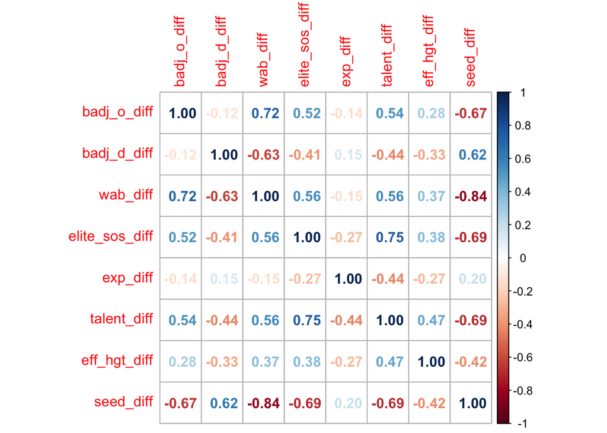

```r
M <- cor(statistics_df %>% select(-outcome))
corrplot(M,method = 'number')
```

In this case we have some room for concern for a couple of the variables. It makes sense to simply remove the seeding difference, as it has relatively high correlation across all of the other predictor variables. It also makes sense to only include either the wins above bubble, or the elite sos metric. In this case the elite sos metric is based on the strength of schedule, whereas the wins above bubble shows how many more wins the team gets than a typical team would. Since the wins above bubble metric contains more information about the team that will be included over the elite sos metric. The only other room for concern is the correlation between the wins above bubble and offensive efficiency metrics. I don’t necessarily view this as an issue, I think the variables encompass different information that moves in the same direction, so both will be included.

# Logistic Regression

Now we can fit a logistic regression model with all of the variables of interest on data up to 2024. We can test the forecasting accuracy of the model on the 2025 March Madness tournament.

```r
model <- glm(outcome ~ badj_o_diff+badj_d_diff+wab_diff+
             exp_diff+talent_diff+eff_hgt_diff, data = model_df_train,
             family = binomial)
summary(model)
```

```
##
## Call:
## glm(formula = outcome ~ badj_o_diff + badj_d_diff + wab_diff +
##     exp_diff + talent_diff + eff_hgt_diff, family = binomial,
##     data = model_df_train)
##
## Coefficients:
##               Estimate Std. Error z value Pr(>|z|)
## (Intercept)  -0.033560   0.079642  -0.421 0.673471
## badj_o_diff   0.049683   0.016847   2.949 0.003188 **
## badj_d_diff  -0.044353   0.019651  -2.257 0.024009 *
## wab_diff      0.098357   0.040917   2.404 0.016226 *
## exp_diff      0.097536   0.145496   0.670 0.502623
## talent_diff   0.009662   0.002825   3.421 0.000625 ***
## eff_hgt_diff -0.055786   0.056614  -0.985 0.324437
## ---
## Signif. codes:  0 '***' 0.001 '**' 0.01 '*' 0.05 '.' 0.1 ' ' 1
##
## (Dispersion parameter for binomial family taken to be 1)
##
##     Null deviance: 1325.2  on 997  degrees of freedom
## Residual deviance: 1103.4  on 991  degrees of freedom
## AIC: 1117.4
##
## Number of Fisher Scoring iterations: 4
```

From this we see that both height and experience weren’t significant in determining the outcome of the game, but talent, offensive/defensive efficiency and wins above bubble are. We can use this model to see how well it can predict the 2025 tournament.

```r
predictions <- predict(model, newdata = model_df_test, type = "response")

predicted_outcome <- ifelse(predictions > 0.5, "win", "loss")

actual_outcome <- model_df_test$outcome

mean(predicted_outcome == actual_outcome)
```

```
## [1] 0.7936508
```

```r
table(predicted = predicted_outcome, actual = actual_outcome)
```

```
##          actual
## predicted loss win
##      loss   11   4
##      win     9  39
```

The model has a really solid testing accuracy already of 79.37%. From the above confusion matrix it appears that the model has a hard time predicting upsets, which makes sense since a lot of the metrics used in the model are considered when seeding the team.

Now we can use backwards selection to narrow down some potential variables.

```r
lmMod <- glm(outcome ~ badj_o_diff+badj_d_diff+wab_diff+
             exp_diff+talent_diff+eff_hgt_diff, data = model_df_train,
             family = binomial)
selectedMod <- step(lmMod)
```

```r
summary(selectedMod)
```

```
##
## Call:
## glm(formula = outcome ~ badj_o_diff + badj_d_diff + wab_diff +
##     talent_diff, family = binomial, data = model_df_train)
##
## Coefficients:
##              Estimate Std. Error z value Pr(>|z|)
## (Intercept) -0.027992   0.079415  -0.352  0.72448
## badj_o_diff  0.049636   0.016794   2.956  0.00312 **
## badj_d_diff -0.042487   0.019510  -2.178  0.02943 *
## wab_diff     0.098930   0.040857   2.421  0.01546 *
## talent_diff  0.008090   0.002474   3.270  0.00108 **
## ---
## Signif. codes:  0 '***' 0.001 '**' 0.01 '*' 0.05 '.' 0.1 ' ' 1
##
## (Dispersion parameter for binomial family taken to be 1)
##
##     Null deviance: 1325.2  on 997  degrees of freedom
## Residual deviance: 1105.0  on 993  degrees of freedom
## AIC: 1115
##
## Number of Fisher Scoring iterations: 4
```

Here we see that backwards selection ended up identifying the model with offensive/defensive efficiency, wins above bubble and talent as the best model. But does it perform as well as the full model when predicting the 2025 tournament?

```r
predictions_glm <- predict(selectedMod, newdata = model_df_test, type = "response")

predicted_outcome_glm <- ifelse(predictions_glm > 0.5, "win", "loss")

actual_outcome <- model_df_test$outcome

mean(predicted_outcome_glm == actual_outcome)
```

```
## [1] 0.7936508
```

```r
table(predicted = predicted_outcome_glm, actual = actual_outcome)
```

```
##          actual
## predicted loss win
##      loss   10   3
##      win    10  40
```

It performs very similarly as the full model, so all of those extra variables were not adding much information that the model was using to predict the outcomes. We can also observe how good the model’s predictions are in the following plot.

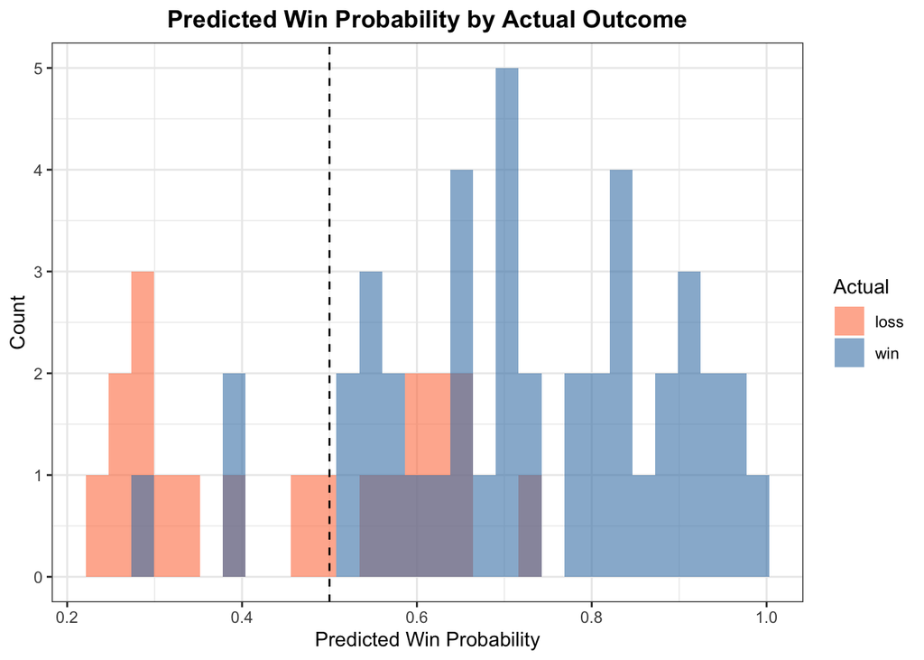

```r
data.frame(probability = predictions_glm, outcome = model_df_test$outcome) %>%
  ggplot(aes(x = probability, fill = outcome)) +
  geom_histogram(bins = 30, alpha = 0.6, position = "identity") +
  scale_fill_manual(values = c("loss" = "coral", "win" = "steelblue")) +
  labs(title = "Predicted Win Probability by Actual Outcome",
       x = "Predicted Win Probability", y = "Count", fill = "Actual") +
  geom_vline(xintercept = 0.5,linetype="dashed")+
  theme_bw() +
  theme(plot.title = element_text(face = "bold", hjust = 0.5),
        plot.subtitle = element_text(hjust = 0.5, color = "grey40"))
```

It is also important to check the ROC curve to make sure the model is performing better than a random classifier.

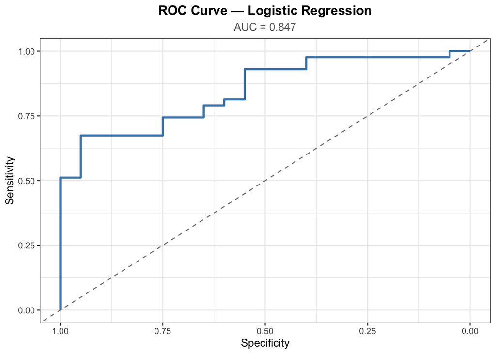

```r
roc_curve <- roc(as.numeric(model_df_test$outcome), predictions)
ggroc(roc_curve, color = "steelblue", linewidth = 1) +
  geom_abline(slope = 1, intercept = 1, linetype = "dashed", color = "grey50") +
  labs(title = "ROC Curve — Logistic Regression",
       subtitle = paste("AUC =", round(auc(roc_curve), 3)),
       x = "Specificity", y = "Sensitivity") +
  theme_bw() +
  theme(plot.title = element_text(face = "bold", hjust = 0.5),
        plot.subtitle = element_text(hjust = 0.5, color = "grey40"))
```

The model looks pretty good, it is significantly better than a random classifier. An AUC value of 0.847 is solid, meaning that given random data that lead to a win the model will correctly identify a higher win probability than random data that lead to a loss 84.7% of the time. We can visualize the decisions the model makes based on offensive and defensive efficiency in the following figure.

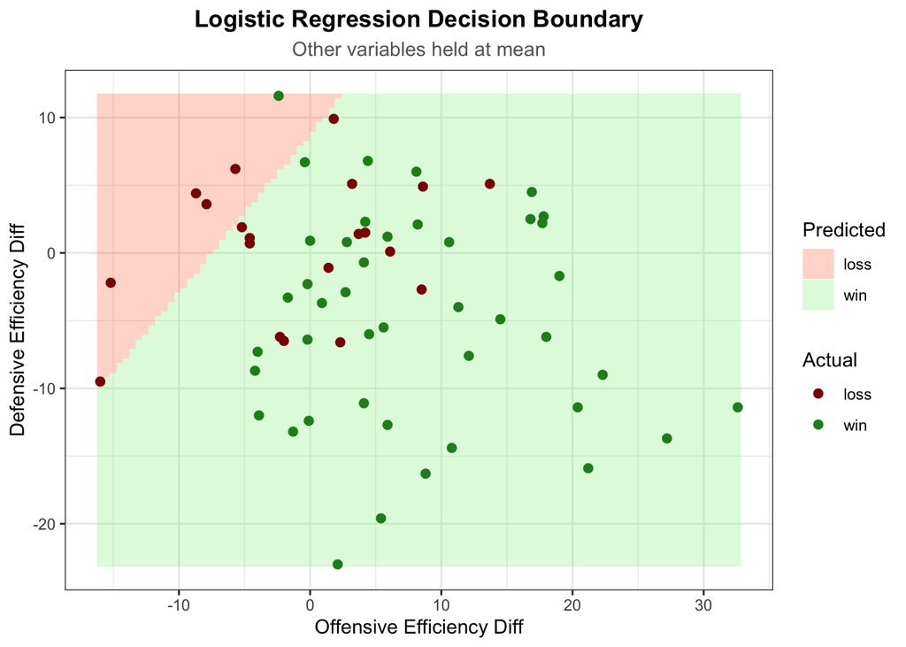

```r
grid <- expand.grid(
  badj_o_diff = seq(min(model_df_test$badj_o_diff),
                    max(model_df_test$badj_o_diff), length = 100),
  badj_d_diff = seq(min(model_df_test$badj_d_diff),
                    max(model_df_test$badj_d_diff), length = 100)
)

grid$wab_diff     <- mean(model_df_test$wab_diff)
grid$talent_diff  <- mean(model_df_test$talent_diff)


grid$pred <- ifelse(predict(selectedMod, newdata = grid, type = "response") > 0.50,
                    "win", "loss")
grid$pred <- factor(grid$pred, levels = c("loss", "win"))

ggplot() +
  geom_tile(data = grid, aes(x = badj_o_diff, y = badj_d_diff, fill = pred),
            alpha = 0.3) +
  geom_point(data = model_df_test,
             aes(x = badj_o_diff, y = badj_d_diff, color = outcome),
             size = 2) +
  scale_fill_manual(values = c("loss" = "coral", "win" = "lightgreen")) +
  scale_color_manual(values = c("loss" = "darkred", "win" = "forestgreen")) +
  labs(title = "Logistic Regression Decision Boundary",
       subtitle = "Other variables held at mean",
       x = "Offensive Efficiency Diff",
       y = "Defensive Efficiency Diff",
       fill = "Predicted", color = "Actual") +
  theme_bw() +
  theme(plot.title = element_text(face = "bold", hjust = 0.5),
        plot.subtitle = element_text(hjust = 0.5, color = "grey40"))
```

One thing that I found particularly interesting is that the model predicts games where the teams have a high defensive efficiency difference but a low offensive efficiency difference as a loss for the high seed. Obviously there are other factors playing a role in the model’s decisions that aren’t being visualized, but it just interesting to see.

I am curious to see how a K nearest neighbors algorithm would behave in this type of problem.

# KNN Algorithm

Now we can train a KNN algorithm on the data to see how it performs relative to the logistic regression. We are gonna fit the model using 1 to 15 neighbors and then use the optimal k value to predict the test set.

```r
trainControl <- trainControl(method="repeatedcv", number=20, repeats=3)
metric <- "Accuracy"

set.seed(7)
grid <- expand.grid(.k=seq(1,15,by=1))
fit.knn <- train(outcome~badj_o_diff+badj_d_diff+wab_diff+talent_diff, data=model_df_train,
             method="knn", metric=metric,tuneGrid=grid ,trControl=trainControl,
             preProcess = c("center", "scale"))
knn.k1 <- fit.knn$bestTune
print(fit.knn)
```

[output not shown]

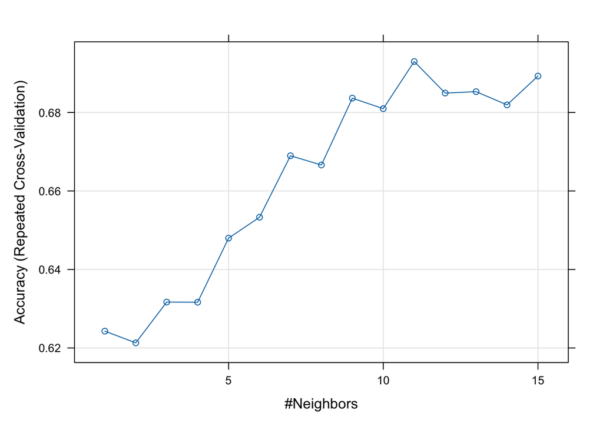

```r
plot(fit.knn)
```

```r
set.seed(7)
prediction <- predict(fit.knn, newdata = model_df_test)
cf <- confusionMatrix(prediction, model_df_test$outcome)
print(cf)
```

```
## Confusion Matrix and Statistics
##
##           Reference
## Prediction loss win
##       loss   12   5
##       win     8  38
##
##                Accuracy : 0.7937
##                  95% CI : (0.673, 0.8853)
##     No Information Rate : 0.6825
##     P-Value [Acc > NIR] : 0.03566
##
##                   Kappa : 0.5039
##
##  Mcnemar's Test P-Value : 0.57910
##
##             Sensitivity : 0.6000
##             Specificity : 0.8837
##          Pos Pred Value : 0.7059
##          Neg Pred Value : 0.8261
##              Prevalence : 0.3175
##          Detection Rate : 0.1905
##    Detection Prevalence : 0.2698
##       Balanced Accuracy : 0.7419
##
##        'Positive' Class : loss
##
```

It looks like it has similar accuracy to the logistic regression model. It still looks like the model has an issue with predicting upsets.

We can look at the decision boundaries again but this time for the KNN model.

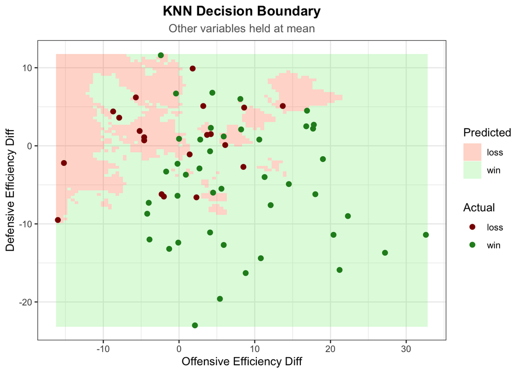

```r
grid <- expand.grid(
  badj_o_diff = seq(min(model_df_test$badj_o_diff),
                    max(model_df_test$badj_o_diff), length = 100),
  badj_d_diff = seq(min(model_df_test$badj_d_diff),
                    max(model_df_test$badj_d_diff), length = 100)
)

grid$wab_diff     <- mean(model_df_test$wab_diff)
grid$talent_diff  <- mean(model_df_test$talent_diff)
grid$seed_diff    <- mean(model_df_test$seed_diff)
grid$exp_diff     <- mean(model_df_test$exp_diff)
grid$eff_hgt_diff <- mean(model_df_test$eff_hgt_diff)

grid$pred <- predict(fit.knn, newdata = grid)

ggplot() +
  geom_tile(data = grid, aes(x = badj_o_diff, y = badj_d_diff, fill = pred),
            alpha = 0.3) +
  geom_point(data = model_df_test,
             aes(x = badj_o_diff, y = badj_d_diff, color = outcome),
             size = 2) +
  scale_fill_manual(values = c("loss" = "coral", "win" = "lightgreen")) +
  scale_color_manual(values = c("loss" = "darkred", "win" = "forestgreen")) +
  labs(title = "KNN Decision Boundary",
       subtitle = "Other variables held at mean",
       x = "Offensive Efficiency Diff",
       y = "Defensive Efficiency Diff",
       fill = "Predicted", color = "Actual") +
  theme_bw() +
  theme(plot.title = element_text(face = "bold", hjust = 0.5),
        plot.subtitle = element_text(hjust = 0.5, color = "grey40"))
```

The decision boundary has some of the same areas being predicted as a loss as the logistic regression. The top left corner seems to be where the models expect losses to occur.

Overall the logistic regression and the KNN models had similar predictive power. The KNN model seemed to be a little better at identifying where upsets occurred, but was slightly worse at identifying when the high seed was going to win.

How do these stack up to a neural network fit on the same model parameters? I know that neural networks do not usually work well on smaller data sets, but I want to give it a try and see what happens.

# Neural Network

```r
nnet_grid <- expand.grid(size = c(1,2,3,4,5,6,7,8,9,10),
                         decay = c(0.001, 0.01, 0.1))

fit.nnet <- train(outcome~badj_o_diff+badj_d_diff+wab_diff+talent_diff,
                  data = model_df_train, method ="nnet",
                  metric = metric, trControl = trainControl,
                  preProcess = c("center", "scale"),
                  tuneGrid = nnet_grid,maxit=500)
```

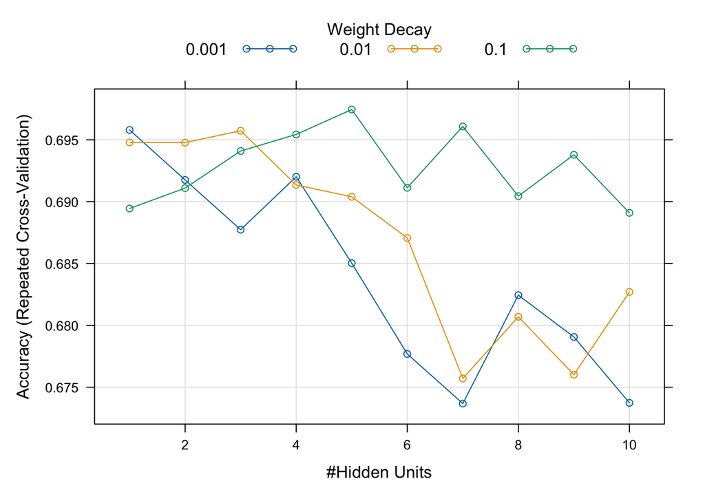

```r
plot(fit.nnet)
```

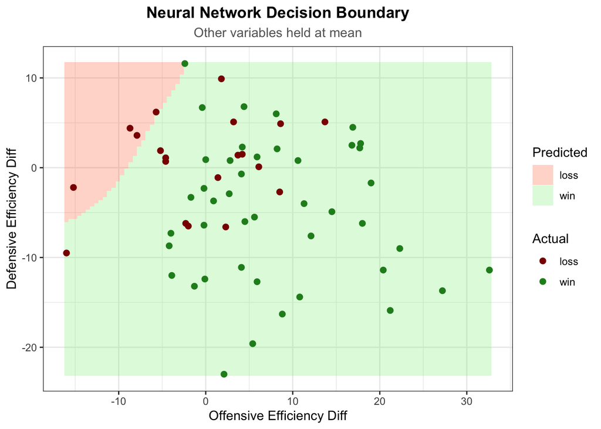

```r
grid <- expand.grid(
  badj_o_diff = seq(min(model_df_test$badj_o_diff),
                    max(model_df_test$badj_o_diff), length = 100),
  badj_d_diff = seq(min(model_df_test$badj_d_diff),
                    max(model_df_test$badj_d_diff), length = 100)
)

grid$wab_diff     <- mean(model_df_test$wab_diff)
grid$talent_diff  <- mean(model_df_test$talent_diff)

grid$pred <- predict(fit.nnet, newdata = grid)

ggplot() +
  geom_tile(data = grid, aes(x = badj_o_diff, y = badj_d_diff, fill = pred),
            alpha = 0.3) +
  geom_point(data = model_df_test,
             aes(x = badj_o_diff, y = badj_d_diff, color = outcome),
             size = 2) +
  scale_fill_manual(values = c("loss" = "coral", "win" = "lightgreen")) +
  scale_color_manual(values = c("loss" = "darkred", "win" = "forestgreen")) +
  labs(title = "Neural Network Decision Boundary",
       subtitle = "Other variables held at mean",
       x = "Offensive Efficiency Diff",
       y = "Defensive Efficiency Diff",
       fill = "Predicted", color = "Actual") +
  theme_bw() +
  theme(plot.title = element_text(face = "bold", hjust = 0.5),
        plot.subtitle = element_text(hjust = 0.5, color = "grey40"))
```

# Random Forest

```r
fit.rf <- train(outcome~badj_o_diff+badj_d_diff+wab_diff+talent_diff,
                data = model_df_train,
             method = "rf", metric = metric,trControl = trainControl,
             preProcess = c("center", "scale"),ntree=500)
```

```r
prediction_rf <- predict(fit.rf, newdata = model_df_test)
confusionMatrix(prediction_rf, model_df_test$outcome)
```

```
## Confusion Matrix and Statistics
##
##           Reference
## Prediction loss win
##       loss   12   6
##       win     8  37
##
##                Accuracy : 0.7778
##                  95% CI : (0.6554, 0.8728)
##     No Information Rate : 0.6825
##     P-Value [Acc > NIR] : 0.06508
##
##                   Kappa : 0.4731
##
##  Mcnemar's Test P-Value : 0.78927
##
##             Sensitivity : 0.6000
##             Specificity : 0.8605
##          Pos Pred Value : 0.6667
##          Neg Pred Value : 0.8222
##              Prevalence : 0.3175
##          Detection Rate : 0.1905
##    Detection Prevalence : 0.2857
##       Balanced Accuracy : 0.7302
##
##        'Positive' Class : loss
##
```

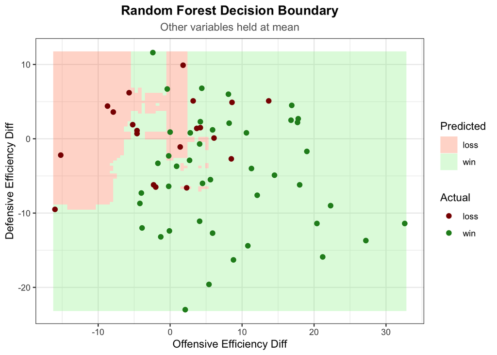

```r
grid <- expand.grid(
  badj_o_diff = seq(min(model_df_test$badj_o_diff),
                    max(model_df_test$badj_o_diff), length = 100),
  badj_d_diff = seq(min(model_df_test$badj_d_diff),
                    max(model_df_test$badj_d_diff), length = 100)
)

grid$wab_diff     <- mean(model_df_test$wab_diff)
grid$talent_diff  <- mean(model_df_test$talent_diff)

grid$pred <- predict(fit.rf, newdata = grid)

ggplot() +
  geom_tile(data = grid, aes(x = badj_o_diff, y = badj_d_diff, fill = pred),
            alpha = 0.3) +
  geom_point(data = model_df_test,
             aes(x = badj_o_diff, y = badj_d_diff, color = outcome),
             size = 2) +
  scale_fill_manual(values = c("loss" = "coral", "win" = "lightgreen")) +
  scale_color_manual(values = c("loss" = "darkred", "win" = "forestgreen")) +
  labs(title = "Random Forest Decision Boundary",
       subtitle = "Other variables held at mean",
       x = "Offensive Efficiency Diff",
       y = "Defensive Efficiency Diff",
       fill = "Predicted", color = "Actual") +
  theme_bw() +
  theme(plot.title = element_text(face = "bold", hjust = 0.5),
        plot.subtitle = element_text(hjust = 0.5, color = "grey40"))
```

# Gradient Boosting

```r
fit.gbm <- train(outcome ~badj_o_diff+badj_d_diff+wab_diff+talent_diff,
             data = model_df_train, method = "gbm", metric = metric,
             trControl = trainControl, preProcess = c("center", "scale"))
```

```r
prediction_gbm <- predict(fit.gbm, newdata = model_df_test)
confusionMatrix(prediction_gbm, model_df_test$outcome)
```

```
## Confusion Matrix and Statistics
##
##           Reference
## Prediction loss win
##       loss   11   4
##       win     9  39
##
##                Accuracy : 0.7937
##                  95% CI : (0.673, 0.8853)
##     No Information Rate : 0.6825
##     P-Value [Acc > NIR] : 0.03566
##
##                   Kappa : 0.4897
##
##  Mcnemar's Test P-Value : 0.26726
##
##             Sensitivity : 0.5500
##             Specificity : 0.9070
##          Pos Pred Value : 0.7333
##          Neg Pred Value : 0.8125
##              Prevalence : 0.3175
##          Detection Rate : 0.1746
##    Detection Prevalence : 0.2381
##       Balanced Accuracy : 0.7285
##
##        'Positive' Class : loss
##
```

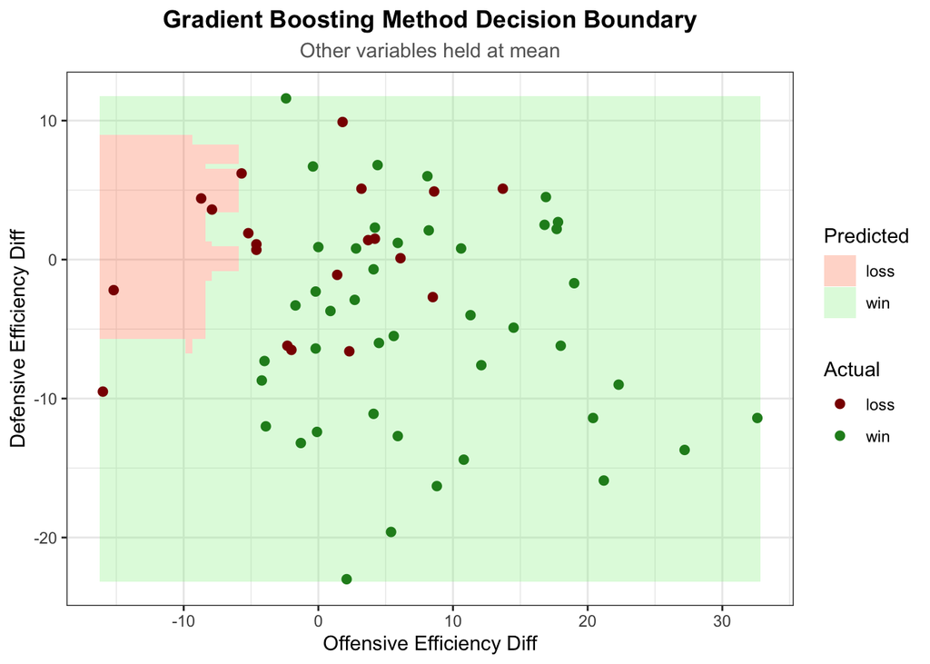

```r
grid <- expand.grid(
  badj_o_diff = seq(min(model_df_test$badj_o_diff),
                    max(model_df_test$badj_o_diff), length = 100),
  badj_d_diff = seq(min(model_df_test$badj_d_diff),
                    max(model_df_test$badj_d_diff), length = 100)
)

grid$wab_diff     <- mean(model_df_test$wab_diff)
grid$talent_diff  <- mean(model_df_test$talent_diff)

grid$pred <- predict(fit.gbm, newdata = grid)

ggplot() +
  geom_tile(data = grid, aes(x = badj_o_diff, y = badj_d_diff, fill = pred),
            alpha = 0.3) +
  geom_point(data = model_df_test,
             aes(x = badj_o_diff, y = badj_d_diff, color = outcome),
             size = 2) +
  scale_fill_manual(values = c("loss" = "coral", "win" = "lightgreen")) +
  scale_color_manual(values = c("loss" = "darkred", "win" = "forestgreen")) +
  labs(title = "Gradient Boosting Method Decision Boundary",
       subtitle = "Other variables held at mean",
       x = "Offensive Efficiency Diff",
       y = "Defensive Efficiency Diff",
       fill = "Predicted", color = "Actual") +
  theme_bw() +
  theme(plot.title = element_text(face = "bold", hjust = 0.5),
        plot.subtitle = element_text(hjust = 0.5, color = "grey40"))
```

# Summary and Model Selection

Selected the reduced logistic regression to create tournament bracket.

# 2026 Bracket Predictions

```r
bracket_model <- glm(outcome ~ badj_o_diff+badj_d_diff+wab_diff+talent_diff,
                     data = model_df, family = binomial)
summary(bracket_model)
```

```
##
## Call:
## glm(formula = outcome ~ badj_o_diff + badj_d_diff + wab_diff +
##     talent_diff, family = binomial, data = model_df)
##
## Coefficients:
##              Estimate Std. Error z value Pr(>|z|)
## (Intercept) -0.026621   0.077476  -0.344  0.73114
## badj_o_diff  0.050219   0.016286   3.084  0.00205 **
## badj_d_diff -0.041609   0.019016  -2.188  0.02866 *
## wab_diff     0.110872   0.039918   2.778  0.00548 **
## talent_diff  0.007777   0.002399   3.242  0.00119 **
## ---
## Signif. codes:  0 '***' 0.001 '**' 0.01 '*' 0.05 '.' 0.1 ' ' 1
##
## (Dispersion parameter for binomial family taken to be 1)
##
##     Null deviance: 1405.0  on 1060  degrees of freedom
## Residual deviance: 1161.9  on 1056  degrees of freedom
##   (9 observations deleted due to missingness)
## AIC: 1171.9
##
## Number of Fisher Scoring iterations: 4
```

```r
df_26 <- away_neutral %>%
  filter(YEAR == 2026) %>%
  select(c("TEAM","BADJ.O","BADJ.D","WAB","TALENT"))
```